# Module 106

#### Contrast SVE:

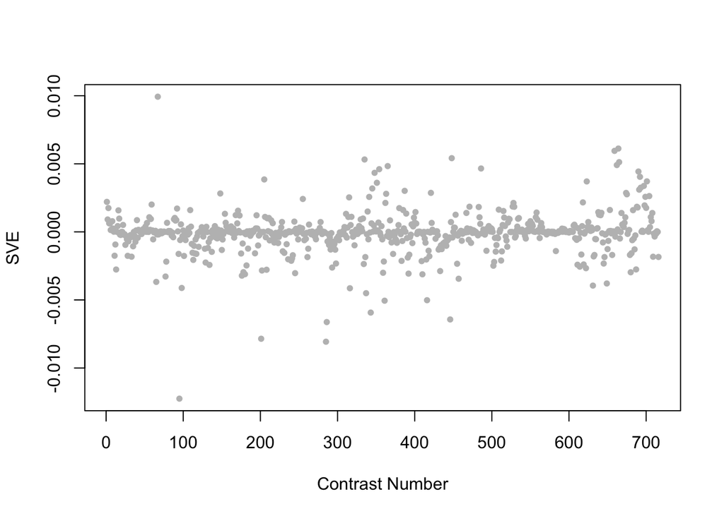

Positive SVE Contrasts:

|  | Contrast.Num | SVE | GEO.GSE | Cond.1 | Cond.2 | Mutation |
| --- | --- | --- | --- | --- | --- | --- |
| GSE8659.s3t1.vs.s2t1 | 67 | 0.01 | GSE8659 | strain NL 2099 replicate 2 | strain GR1373 replicate 1 |  |
| GSE15159.s2t2.vs.s0t2 | 664 | 0.01 | GSE15159 | xpa-1_UV_2007_rep1 | N2_UV_2007_rep1 | xpa-1 |
| GSE15762.s1t1.vs.s0t1 | 659 | 0.01 | GSE15762 | hlh-30(tm1978)-1 | N2-1 | hlh-30 |
| GSE27401.s1t1.vs.s2t1 | 448 | 0.01 | GSE27401 | Heat Killed E coli #1 | Heat Killed C. albicans #1 |  |
| GSE38997.s3t2.vs.s2t2 | 335 | 0.01 | GSE38997 | experiment 4 UVC- and EtBr-exposed samples at 24 h 4eu24 | experiment 4 EtBr-exposed samples at 24 h 4e24 |  |

Negative SVE Contrasts:

|  | Contrast.Num | SVE | GEO.GSE | Cond.1 | Cond.2 | Mutation |
| --- | --- | --- | --- | --- | --- | --- |
| GSE5793.s2t1.vs.s1t1 | 95 | -0.01 | GSE5793 | Celegans_OP50_4hours_RepA | Celegans_gacA_4hours_RepA |  |
| GSE41366C.s2t1.vs.s0t1 | 285 | -0.01 | GSE41366 | high_DDVP-continuous_expose-2h_harvest-rep1 | control-continuous_expose-0h_harvest-rep2 |  |
| GSE43959.s3t2.vs.s3t1 | 201 | -0.01 | GSE43959 | N2 gravid adult on Comamonas DA1877 rep 1 | N2 young adult on Comamonas DA1877 rep 1 |  |
| GSE41366C.s1t1.vs.s0t1 | 286 | -0.01 | GSE41366 | low_DDVP-continuous_expose-2h_harvest-rep1 | control-continuous_expose-0h_harvest-rep2 |  |
| GSE27401.s2t1.vs.s3t1 | 446 | -0.01 | GSE27401 | Heat Killed C. albicans #1 | C. albicans alive #1 |  |

$~$

#### Contrast SVE, Up-Regulated Genes Only:

Calculating SVE for up-regulated and down-regulated genes separately may be more informative in many cases than projecting the up- and down- gene sets together. This is due to the fact that the weight distribution of many modules is highly skewed, indicating that only one of the hemi-modules may be biologically meaningful (i.e., a set of genes are strongly correlated by only a few genes (or none) are strongly anti-correlated to that set.)

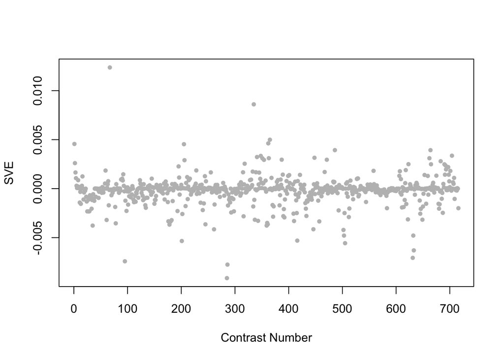

Positive SVE Contrasts:

|  | Contrast.Num | SVE | GEO.GSE | Cond.1 | Cond.2 | Mutation |
| --- | --- | --- | --- | --- | --- | --- |
| GSE8659.s3t1.vs.s2t1 | 67 | 0.01 | GSE8659 | strain NL 2099 replicate 2 | strain GR1373 replicate 1 |  |
| GSE38997.s3t2.vs.s2t2 | 335 | 0.01 | GSE38997 | experiment 4 UVC- and EtBr-exposed samples at 24 h 4eu24 | experiment 4 EtBr-exposed samples at 24 h 4e24 |  |
| GSE36358.s3t1.vs.s0t1 | 365 | 0.00 | GSE36358 | Hyper Gravity | Ground Control (Tsukuba space center) |  |
| GSE37266.s1t1.vs.s0t1 | 362 | 0.00 | GSE37266 | RPW-24 G | DMSO G |  |
| GSE9897A.s1t1.vs.s0t1 | 1 | 0.00 | GSE9897 | Complex I missense mutant | Wildtype (control for missense) | gas-1 |

Negative SVE Contrasts:

|  | Contrast.Num | SVE | GEO.GSE | Cond.1 | Cond.2 | Mutation |
| --- | --- | --- | --- | --- | --- | --- |
| GSE41366C.s2t1.vs.s0t1 | 285 | -0.01 | GSE41366 | high_DDVP-continuous_expose-2h_harvest-rep1 | control-continuous_expose-0h_harvest-rep2 |  |
| GSE41366C.s1t1.vs.s0t1 | 286 | -0.01 | GSE41366 | low_DDVP-continuous_expose-2h_harvest-rep1 | control-continuous_expose-0h_harvest-rep2 |  |
| GSE5793.s2t1.vs.s1t1 | 95 | -0.01 | GSE5793 | Celegans_OP50_4hours_RepA | Celegans_gacA_4hours_RepA |  |
| GSE19310B.s1t4.vs.s1t1 | 631 | -0.01 | GSE19310 | N2 at 200 for 1 generation, rep1 | N2 at 200 for 15min, rep1 |  |
| GSE19310B.s1t3.vs.s1t1 | 633 | -0.01 | GSE19310 | N2 at 200 for 6 hours, rep1 | N2 at 200 for 15min, rep1 |  |

$~$

#### Contrast SVE, Down-Regulated Genes Only:

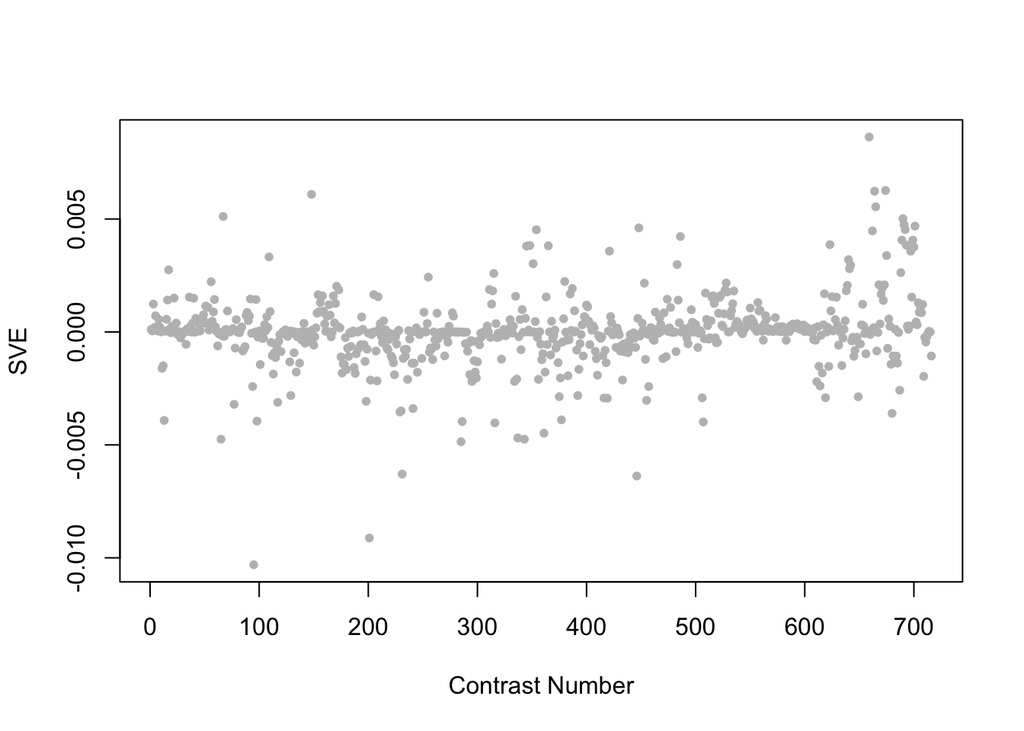

Positive SVE Contrasts:

|  | Contrast.Num | SVE | GEO.GSE | Cond.1 | Cond.2 | Mutation |
| --- | --- | --- | --- | --- | --- | --- |
| GSE15762.s1t1.vs.s0t1 | 659 | 0.01 | GSE15762 | hlh-30(tm1978)-1 | N2-1 | hlh-30 |
| GSE14640C.s1t1.vs.s0t1 | 674 | 0.01 | GSE14640 | XX_SDC2Y93R-P-022208_A | XX_WT-P_081407_A |  |
| GSE15159.s2t2.vs.s0t2 | 664 | 0.01 | GSE15159 | xpa-1_UV_2007_rep1 | N2_UV_2007_rep1 | xpa-1 |
| GSE48347.s2t1.vs.s0t1 | 148 | 0.01 | GSE48347 | sdc2_embryo_rep1 | WT_embryo_rep1 | sdc-2 |
| GSE15159.s1t2.vs.s1t1 | 665 | 0.01 | GSE15159 | glp-1_UV_2007_rep1 | glp-1_control_2007_rep1 |  |

Negative SVE Contrasts:

|  | Contrast.Num | SVE | GEO.GSE | Cond.1 | Cond.2 | Mutation |
| --- | --- | --- | --- | --- | --- | --- |
| GSE5793.s2t1.vs.s1t1 | 95 | -0.01 | GSE5793 | Celegans_OP50_4hours_RepA | Celegans_gacA_4hours_RepA |  |
| GSE43959.s3t2.vs.s3t1 | 201 | -0.01 | GSE43959 | N2 gravid adult on Comamonas DA1877 rep 1 | N2 young adult on Comamonas DA1877 rep 1 |  |
| GSE27401.s2t1.vs.s3t1 | 446 | -0.01 | GSE27401 | Heat Killed C. albicans #1 | C. albicans alive #1 |  |
| GSE42592B.s2t3.vs.s0t3 | 231 | -0.01 | GSE42592 | cadmium_mid_expose-8h_rep1 | cadmium_control_expose-8h_rep1 |  |
| GSE41366C.s2t1.vs.s0t1 | 285 | -0.00 | GSE41366 | high_DDVP-continuous_expose-2h_harvest-rep1 | control-continuous_expose-0h_harvest-rep2 |  |

$~$

$~$

#### GO Term Enrichment:

This analysis tests each hemi-module for enrichment of specific GO terms. Only gene-level annotations (e.g., as would be found on the gene’s page in Wormbase) are tested - the hierarchical structure of the GO ontology is not taken into account.

*Note: At least the top two most enriched terms from each GO domain (BP/MF/CC) are shown, even when not statistically significant.*

##### Enriched GO terms: Hemi-module A

| ID | GO.Term | GO Domain | Raw p-value | Adj p-value |
| --- | --- | --- | --- | --- |
| [GO_0006450](http://amigo.geneontology.org/amigo/term/GO:0006450) | regulation of translational fidelity | BP | 4.65e-03 | 1.00e+00 |
| [GO_0007214](http://amigo.geneontology.org/amigo/term/GO:0007214) | gamma-aminobutyric acid signaling pathway | BP | 6.97e-03 | 1.00e+00 |
| [GO_0030246](http://amigo.geneontology.org/amigo/term/GO:0030246) | carbohydrate binding | MF | 2.01e-04 | 4.10e-01 |
| [GO_0031177](http://amigo.geneontology.org/amigo/term/GO:0031177) | phosphopantetheine binding | MF | 4.65e-03 | 1.00e+00 |
| [GO_0030956](http://amigo.geneontology.org/amigo/term/GO:0030956) | glutamyl-tRNA(Gln) amidotransferase complex | CC | 6.97e-03 | 1.00e+00 |
| [GO_0098794](http://amigo.geneontology.org/amigo/term/GO:0098794) | postsynapse | CC | 1.39e-02 | 1.00e+00 |

##### Enriched GO terms: Hemi-module B

| ID | GO.Term | GO Domain | Raw p-value | Adj p-value |
| --- | --- | --- | --- | --- |
| [GO_0006557](http://amigo.geneontology.org/amigo/term/GO:0006557) | S-adenosylmethioninamine biosynthetic process | BP | 2.08e-03 | 1.00e+00 |
| [GO_0006597](http://amigo.geneontology.org/amigo/term/GO:0006597) | spermine biosynthetic process | BP | 2.08e-03 | 1.00e+00 |
| [GO_0051287](http://amigo.geneontology.org/amigo/term/GO:0051287) | NAD binding | MF | 5.53e-04 | 9.53e-01 |
| [GO_0016616](http://amigo.geneontology.org/amigo/term/GO:0016616) | oxidoreductase activity, acting on the CH-OH group of donors, NAD or NADP as acceptor | MF | 9.33e-04 | 9.53e-01 |
| [GO_0030659](http://amigo.geneontology.org/amigo/term/GO:0030659) | cytoplasmic vesicle membrane | CC | 8.50e-04 | 6.42e-01 |
| [GO_0005829](http://amigo.geneontology.org/amigo/term/GO:0005829) | cytosol | CC | 1.48e-03 | 6.42e-01 |

$~$

$~$

#### Tissue Enrichment:

This analysis tests each hemi-module for enrichment of genes associated with anatomy terms. Negative enrichment scores indicate fewer hemi-module genes than expected by random chance were associated with the anatomy term in question.

##### Enriched tissues: Hemi-module A

No significant annotations.

##### Enriched tissues: Hemi-module B

No significant annotations.

$~$

$~$

#### HOMER promoter motif enrichment:

This analysis tests each hemi-module for enrichment of 108 known *C. elegans* transcription factor binding site motifs (see [108 CE motifs](https://katiepod.github.io//all.worm.motifs.html)) using the HOMER (Hypergeometric Optimization of Motif EnRichment) software (see [PMID:20513432](https://pubmed.ncbi.nlm.nih.gov/20513432)). HOMER was run using default parameters on sequences 1 kb upstream of the transcription start site.

##### Motif enrichment: Hemi-module A

Total target sequences = 39  
Total background sequences = 40250  
* - possible false positive

Rank

Motif

P-value

log P-pvalue

% of Targets

% of Background

STD(Bg STD)

Best Match/Details

Motif File

1 *

[figure not shown]

1e-10

-2.433e+01

30.77%

2.17%

213.2bp (288.2bp)

POL002.1_INR/Jaspar(0.518)  
[More Information](https://katiepod.github.io/HomerResults/m106_a_hemi_genes.txt.out.1kb/homerResults/motif1.info.html) | [Similar Motifs Found](https://katiepod.github.io/HomerResults/m106_a_hemi_genes.txt.out.1kb/homerResults/motif1.similar.html)

[motif file (matrix)](https://katiepod.github.io/HomerResults/m106_a_hemi_genes.txt.out.1kb/homerResults/motif1.motif)

2 *

[figure not shown]

1e-8

-1.948e+01

10.26%

0.04%

308.0bp (265.3bp)

MF0007.1_bHLH(zip)_class/Jaspar(0.643)  
[More Information](https://katiepod.github.io/HomerResults/m106_a_hemi_genes.txt.out.1kb/homerResults/motif2.info.html) | [Similar Motifs Found](https://katiepod.github.io/HomerResults/m106_a_hemi_genes.txt.out.1kb/homerResults/motif2.similar.html)

[motif file (matrix)](https://katiepod.github.io/HomerResults/m106_a_hemi_genes.txt.out.1kb/homerResults/motif2.motif)

3 *

[figure not shown]

1e-8

-1.939e+01

17.95%

0.60%

311.2bp (313.9bp)

MF0001.1_ETS_class/Jaspar(0.558)  
[More Information](https://katiepod.github.io/HomerResults/m106_a_hemi_genes.txt.out.1kb/homerResults/motif3.info.html) | [Similar Motifs Found](https://katiepod.github.io/HomerResults/m106_a_hemi_genes.txt.out.1kb/homerResults/motif3.similar.html)

[motif file (matrix)](https://katiepod.github.io/HomerResults/m106_a_hemi_genes.txt.out.1kb/homerResults/motif3.motif)

4 *

[figure not shown]

1e-7

-1.758e+01

17.95%

0.78%

240.3bp (290.0bp)

EGL-5(Homeobox)/cElegans-L3-EGL5-ChIP-Seq(modEncode)/Homer(0.645)  
[More Information](https://katiepod.github.io/HomerResults/m106_a_hemi_genes.txt.out.1kb/homerResults/motif4.info.html) | [Similar Motifs Found](https://katiepod.github.io/HomerResults/m106_a_hemi_genes.txt.out.1kb/homerResults/motif4.similar.html)

[motif file (matrix)](https://katiepod.github.io/HomerResults/m106_a_hemi_genes.txt.out.1kb/homerResults/motif4.motif)

5 *

[figure not shown]

1e-6

-1.578e+01

12.82%

0.30%

277.4bp (307.2bp)

atf-7/MA1438.1/Jaspar(0.620)  
[More Information](https://katiepod.github.io/HomerResults/m106_a_hemi_genes.txt.out.1kb/homerResults/motif5.info.html) | [Similar Motifs Found](https://katiepod.github.io/HomerResults/m106_a_hemi_genes.txt.out.1kb/homerResults/motif5.similar.html)

[motif file (matrix)](https://katiepod.github.io/HomerResults/m106_a_hemi_genes.txt.out.1kb/homerResults/motif5.motif)

6 *

[figure not shown]

1e-6

-1.544e+01

12.82%

0.32%

173.6bp (289.6bp)

elt-6/MA1439.1/Jaspar(0.646)  
[More Information](https://katiepod.github.io/HomerResults/m106_a_hemi_genes.txt.out.1kb/homerResults/motif6.info.html) | [Similar Motifs Found](https://katiepod.github.io/HomerResults/m106_a_hemi_genes.txt.out.1kb/homerResults/motif6.similar.html)

[motif file (matrix)](https://katiepod.github.io/HomerResults/m106_a_hemi_genes.txt.out.1kb/homerResults/motif6.motif)

7 *

[figure not shown]

1e-6

-1.414e+01

23.08%

2.67%

298.4bp (307.7bp)

mab-3/MA0262.1/Jaspar(0.680)  
[More Information](https://katiepod.github.io/HomerResults/m106_a_hemi_genes.txt.out.1kb/homerResults/motif7.info.html) | [Similar Motifs Found](https://katiepod.github.io/HomerResults/m106_a_hemi_genes.txt.out.1kb/homerResults/motif7.similar.html)

[motif file (matrix)](https://katiepod.github.io/HomerResults/m106_a_hemi_genes.txt.out.1kb/homerResults/motif7.motif)

8 *

[figure not shown]

1e-4

-1.147e+01

23.08%

3.71%

251.7bp (304.1bp)

ceh-28/MA1445.1/Jaspar(0.539)  
[More Information](https://katiepod.github.io/HomerResults/m106_a_hemi_genes.txt.out.1kb/homerResults/motif8.info.html) | [Similar Motifs Found](https://katiepod.github.io/HomerResults/m106_a_hemi_genes.txt.out.1kb/homerResults/motif8.similar.html)

[motif file (matrix)](https://katiepod.github.io/HomerResults/m106_a_hemi_genes.txt.out.1kb/homerResults/motif8.motif)

9 *

[figure not shown]

1e-4

-1.098e+01

10.26%

0.39%

198.1bp (323.6bp)

POL013.1_MED-1/Jaspar(0.537)  
[More Information](https://katiepod.github.io/HomerResults/m106_a_hemi_genes.txt.out.1kb/homerResults/motif9.info.html) | [Similar Motifs Found](https://katiepod.github.io/HomerResults/m106_a_hemi_genes.txt.out.1kb/homerResults/motif9.similar.html)

[motif file (matrix)](https://katiepod.github.io/HomerResults/m106_a_hemi_genes.txt.out.1kb/homerResults/motif9.motif)

10 *

[figure not shown]

1e-4

-1.076e+01

12.82%

0.85%

293.2bp (285.4bp)

MF0009.1_TRP(MYB)_class/Jaspar(0.635)  
[More Information](https://katiepod.github.io/HomerResults/m106_a_hemi_genes.txt.out.1kb/homerResults/motif10.info.html) | [Similar Motifs Found](https://katiepod.github.io/HomerResults/m106_a_hemi_genes.txt.out.1kb/homerResults/motif10.similar.html)

[motif file (matrix)](https://katiepod.github.io/HomerResults/m106_a_hemi_genes.txt.out.1kb/homerResults/motif10.motif)

11 *

[figure not shown]

1e-4

-1.012e+01

5.13%

0.02%

395.5bp (350.5bp)

MF0002.1_bZIP_CREB/G-box-like_subclass/Jaspar(0.716)  
[More Information](https://katiepod.github.io/HomerResults/m106_a_hemi_genes.txt.out.1kb/homerResults/motif11.info.html) | [Similar Motifs Found](https://katiepod.github.io/HomerResults/m106_a_hemi_genes.txt.out.1kb/homerResults/motif11.similar.html)

[motif file (matrix)](https://katiepod.github.io/HomerResults/m106_a_hemi_genes.txt.out.1kb/homerResults/motif11.motif)

12 *

[figure not shown]

1e-4

-9.622e+00

28.21%

7.17%

285.2bp (300.1bp)

elt-6/MA1439.1/Jaspar(0.723)  
[More Information](https://katiepod.github.io/HomerResults/m106_a_hemi_genes.txt.out.1kb/homerResults/motif12.info.html) | [Similar Motifs Found](https://katiepod.github.io/HomerResults/m106_a_hemi_genes.txt.out.1kb/homerResults/motif12.similar.html)

[motif file (matrix)](https://katiepod.github.io/HomerResults/m106_a_hemi_genes.txt.out.1kb/homerResults/motif12.motif)

13 *

[figure not shown]

1e-4

-9.401e+00

25.64%

6.05%

275.7bp (307.3bp)

unc-30/MA1443.1/Jaspar(0.648)  
[More Information](https://katiepod.github.io/HomerResults/m106_a_hemi_genes.txt.out.1kb/homerResults/motif13.info.html) | [Similar Motifs Found](https://katiepod.github.io/HomerResults/m106_a_hemi_genes.txt.out.1kb/homerResults/motif13.similar.html)

[motif file (matrix)](https://katiepod.github.io/HomerResults/m106_a_hemi_genes.txt.out.1kb/homerResults/motif13.motif)

14 *

[figure not shown]

1e-4

-9.396e+00

33.33%

10.22%

212.2bp (307.9bp)

POL008.1_DCE_S_I/Jaspar(0.594)  
[More Information](https://katiepod.github.io/HomerResults/m106_a_hemi_genes.txt.out.1kb/homerResults/motif14.info.html) | [Similar Motifs Found](https://katiepod.github.io/HomerResults/m106_a_hemi_genes.txt.out.1kb/homerResults/motif14.similar.html)

[motif file (matrix)](https://katiepod.github.io/HomerResults/m106_a_hemi_genes.txt.out.1kb/homerResults/motif14.motif)

15 *

[figure not shown]

1e-4

-9.277e+00

5.13%

0.03%

147.1bp (182.0bp)

unc-86/MA0926.1/Jaspar(0.701)  
[More Information](https://katiepod.github.io/HomerResults/m106_a_hemi_genes.txt.out.1kb/homerResults/motif15.info.html) | [Similar Motifs Found](https://katiepod.github.io/HomerResults/m106_a_hemi_genes.txt.out.1kb/homerResults/motif15.similar.html)

[motif file (matrix)](https://katiepod.github.io/HomerResults/m106_a_hemi_genes.txt.out.1kb/homerResults/motif15.motif)

16 *

[figure not shown]

1e-3

-9.056e+00

7.69%

0.24%

260.1bp (338.6bp)

SD0003.1_at_AC_acceptor/Jaspar(0.684)  
[More Information](https://katiepod.github.io/HomerResults/m106_a_hemi_genes.txt.out.1kb/homerResults/motif16.info.html) | [Similar Motifs Found](https://katiepod.github.io/HomerResults/m106_a_hemi_genes.txt.out.1kb/homerResults/motif16.similar.html)

[motif file (matrix)](https://katiepod.github.io/HomerResults/m106_a_hemi_genes.txt.out.1kb/homerResults/motif16.motif)

##### Motif enrichment: Hemi-module B

Total target sequences = 32  
Total background sequences = 37538  
* - possible false positive

Rank

Motif

P-value

log P-pvalue

% of Targets

% of Background

STD(Bg STD)

Best Match/Details

Motif File

1 *

[figure not shown]

1e-9

-2.229e+01

12.50%

0.02%

188.7bp (258.2bp)

POL010.1_DCE_S_III/Jaspar(0.534)  
[More Information](https://katiepod.github.io/HomerResults/m106_b_hemi_genes.txt.out.1kb/homerResults/motif1.info.html) | [Similar Motifs Found](https://katiepod.github.io/HomerResults/m106_b_hemi_genes.txt.out.1kb/homerResults/motif1.similar.html)

[motif file (matrix)](https://katiepod.github.io/HomerResults/m106_b_hemi_genes.txt.out.1kb/homerResults/motif1.motif)

2 *

[figure not shown]

1e-9

-2.163e+01

21.88%

0.53%

339.3bp (285.2bp)

pqm-1/MA1703.1/Jaspar(0.841)  
[More Information](https://katiepod.github.io/HomerResults/m106_b_hemi_genes.txt.out.1kb/homerResults/motif2.info.html) | [Similar Motifs Found](https://katiepod.github.io/HomerResults/m106_b_hemi_genes.txt.out.1kb/homerResults/motif2.similar.html)

[motif file (matrix)](https://katiepod.github.io/HomerResults/m106_b_hemi_genes.txt.out.1kb/homerResults/motif2.motif)

3 *

[figure not shown]

1e-8

-1.890e+01

21.88%

0.80%

294.4bp (314.2bp)

lin-14/MA0261.1/Jaspar(0.722)  
[More Information](https://katiepod.github.io/HomerResults/m106_b_hemi_genes.txt.out.1kb/homerResults/motif3.info.html) | [Similar Motifs Found](https://katiepod.github.io/HomerResults/m106_b_hemi_genes.txt.out.1kb/homerResults/motif3.similar.html)

[motif file (matrix)](https://katiepod.github.io/HomerResults/m106_b_hemi_genes.txt.out.1kb/homerResults/motif3.motif)

4 *

[figure not shown]

1e-8

-1.857e+01

12.50%

0.07%

198.7bp (283.1bp)

fkh-9/MA1440.1/Jaspar(0.617)  
[More Information](https://katiepod.github.io/HomerResults/m106_b_hemi_genes.txt.out.1kb/homerResults/motif4.info.html) | [Similar Motifs Found](https://katiepod.github.io/HomerResults/m106_b_hemi_genes.txt.out.1kb/homerResults/motif4.similar.html)

[motif file (matrix)](https://katiepod.github.io/HomerResults/m106_b_hemi_genes.txt.out.1kb/homerResults/motif4.motif)

5 *

[figure not shown]

1e-7

-1.838e+01

18.75%

0.48%

222.7bp (357.3bp)

zip-8/MA1704.1/Jaspar(0.680)  
[More Information](https://katiepod.github.io/HomerResults/m106_b_hemi_genes.txt.out.1kb/homerResults/motif5.info.html) | [Similar Motifs Found](https://katiepod.github.io/HomerResults/m106_b_hemi_genes.txt.out.1kb/homerResults/motif5.similar.html)

[motif file (matrix)](https://katiepod.github.io/HomerResults/m106_b_hemi_genes.txt.out.1kb/homerResults/motif5.motif)

6 *

[figure not shown]

1e-7

-1.816e+01

21.88%

0.89%

261.8bp (337.8bp)

ceh-38/MA1699.1/Jaspar(0.595)  
[More Information](https://katiepod.github.io/HomerResults/m106_b_hemi_genes.txt.out.1kb/homerResults/motif6.info.html) | [Similar Motifs Found](https://katiepod.github.io/HomerResults/m106_b_hemi_genes.txt.out.1kb/homerResults/motif6.similar.html)

[motif file (matrix)](https://katiepod.github.io/HomerResults/m106_b_hemi_genes.txt.out.1kb/homerResults/motif6.motif)

7 *

[figure not shown]

1e-7

-1.815e+01

12.50%

0.07%

328.8bp (308.7bp)

snpc-4/MA0544.1/Jaspar(0.493)  
[More Information](https://katiepod.github.io/HomerResults/m106_b_hemi_genes.txt.out.1kb/homerResults/motif7.info.html) | [Similar Motifs Found](https://katiepod.github.io/HomerResults/m106_b_hemi_genes.txt.out.1kb/homerResults/motif7.similar.html)

[motif file (matrix)](https://katiepod.github.io/HomerResults/m106_b_hemi_genes.txt.out.1kb/homerResults/motif7.motif)

8 *

[figure not shown]

1e-6

-1.545e+01

15.62%

0.40%

190.3bp (344.1bp)

skn-1/MA0547.1/Jaspar(0.669)  
[More Information](https://katiepod.github.io/HomerResults/m106_b_hemi_genes.txt.out.1kb/homerResults/motif8.info.html) | [Similar Motifs Found](https://katiepod.github.io/HomerResults/m106_b_hemi_genes.txt.out.1kb/homerResults/motif8.similar.html)

[motif file (matrix)](https://katiepod.github.io/HomerResults/m106_b_hemi_genes.txt.out.1kb/homerResults/motif8.motif)

9 *

[figure not shown]

1e-6

-1.522e+01

37.50%

6.24%

221.1bp (352.4bp)

blmp-1/MA0537.1/Jaspar(0.634)  
[More Information](https://katiepod.github.io/HomerResults/m106_b_hemi_genes.txt.out.1kb/homerResults/motif9.info.html) | [Similar Motifs Found](https://katiepod.github.io/HomerResults/m106_b_hemi_genes.txt.out.1kb/homerResults/motif9.similar.html)

[motif file (matrix)](https://katiepod.github.io/HomerResults/m106_b_hemi_genes.txt.out.1kb/homerResults/motif9.motif)

10 *

[figure not shown]

1e-6

-1.476e+01

15.62%

0.46%

268.7bp (294.4bp)

PHA-4(Forkhead)/cElegans-Embryos-PHA4-ChIP-Seq(modEncode)/Homer(0.691)  
[More Information](https://katiepod.github.io/HomerResults/m106_b_hemi_genes.txt.out.1kb/homerResults/motif10.info.html) | [Similar Motifs Found](https://katiepod.github.io/HomerResults/m106_b_hemi_genes.txt.out.1kb/homerResults/motif10.similar.html)

[motif file (matrix)](https://katiepod.github.io/HomerResults/m106_b_hemi_genes.txt.out.1kb/homerResults/motif10.motif)

11 *

[figure not shown]

1e-6

-1.433e+01

28.12%

3.26%

296.5bp (336.7bp)

che-1/MA0260.1/Jaspar(0.600)  
[More Information](https://katiepod.github.io/HomerResults/m106_b_hemi_genes.txt.out.1kb/homerResults/motif11.info.html) | [Similar Motifs Found](https://katiepod.github.io/HomerResults/m106_b_hemi_genes.txt.out.1kb/homerResults/motif11.similar.html)

[motif file (matrix)](https://katiepod.github.io/HomerResults/m106_b_hemi_genes.txt.out.1kb/homerResults/motif11.motif)

12 *

[figure not shown]

1e-6

-1.418e+01

15.62%

0.52%

227.7bp (309.2bp)

che-1/MA0260.1/Jaspar(0.547)  
[More Information](https://katiepod.github.io/HomerResults/m106_b_hemi_genes.txt.out.1kb/homerResults/motif12.info.html) | [Similar Motifs Found](https://katiepod.github.io/HomerResults/m106_b_hemi_genes.txt.out.1kb/homerResults/motif12.similar.html)

[motif file (matrix)](https://katiepod.github.io/HomerResults/m106_b_hemi_genes.txt.out.1kb/homerResults/motif12.motif)

13 *

[figure not shown]

1e-6

-1.405e+01

43.75%

9.96%

270.9bp (397.3bp)

POL003.1_GC-box/Jaspar(0.729)  
[More Information](https://katiepod.github.io/HomerResults/m106_b_hemi_genes.txt.out.1kb/homerResults/motif13.info.html) | [Similar Motifs Found](https://katiepod.github.io/HomerResults/m106_b_hemi_genes.txt.out.1kb/homerResults/motif13.similar.html)

[motif file (matrix)](https://katiepod.github.io/HomerResults/m106_b_hemi_genes.txt.out.1kb/homerResults/motif13.motif)

14 *

[figure not shown]

1e-6

-1.399e+01

9.38%

0.05%

320.4bp (329.6bp)

POL009.1_DCE_S_II/Jaspar(0.555)  
[More Information](https://katiepod.github.io/HomerResults/m106_b_hemi_genes.txt.out.1kb/homerResults/motif14.info.html) | [Similar Motifs Found](https://katiepod.github.io/HomerResults/m106_b_hemi_genes.txt.out.1kb/homerResults/motif14.similar.html)

[motif file (matrix)](https://katiepod.github.io/HomerResults/m106_b_hemi_genes.txt.out.1kb/homerResults/motif14.motif)

15 *

[figure not shown]

1e-5

-1.313e+01

9.38%

0.07%

295.5bp (364.7bp)

POL001.1_MTE/Jaspar(0.503)  
[More Information](https://katiepod.github.io/HomerResults/m106_b_hemi_genes.txt.out.1kb/homerResults/motif15.info.html) | [Similar Motifs Found](https://katiepod.github.io/HomerResults/m106_b_hemi_genes.txt.out.1kb/homerResults/motif15.similar.html)

[motif file (matrix)](https://katiepod.github.io/HomerResults/m106_b_hemi_genes.txt.out.1kb/homerResults/motif15.motif)

16 *

[figure not shown]

1e-5

-1.289e+01

18.75%

1.23%

280.8bp (376.4bp)

POL008.1_DCE_S_I/Jaspar(0.615)  
[More Information](https://katiepod.github.io/HomerResults/m106_b_hemi_genes.txt.out.1kb/homerResults/motif16.info.html) | [Similar Motifs Found](https://katiepod.github.io/HomerResults/m106_b_hemi_genes.txt.out.1kb/homerResults/motif16.similar.html)

[motif file (matrix)](https://katiepod.github.io/HomerResults/m106_b_hemi_genes.txt.out.1kb/homerResults/motif16.motif)

17 *

[figure not shown]

1e-4

-1.064e+01

59.38%

24.24%

305.1bp (325.5bp)

hlh-1/MA0545.1/Jaspar(0.817)  
[More Information](https://katiepod.github.io/HomerResults/m106_b_hemi_genes.txt.out.1kb/homerResults/motif17.info.html) | [Similar Motifs Found](https://katiepod.github.io/HomerResults/m106_b_hemi_genes.txt.out.1kb/homerResults/motif17.similar.html)

[motif file (matrix)](https://katiepod.github.io/HomerResults/m106_b_hemi_genes.txt.out.1kb/homerResults/motif17.motif)

18 *

[figure not shown]

1e-3

-9.042e+00

9.38%

0.29%

231.1bp (327.3bp)

SA0002.1_at_AC_acceptor/Jaspar(0.480)  
[More Information](https://katiepod.github.io/HomerResults/m106_b_hemi_genes.txt.out.1kb/homerResults/motif18.info.html) | [Similar Motifs Found](https://katiepod.github.io/HomerResults/m106_b_hemi_genes.txt.out.1kb/homerResults/motif18.similar.html)

[motif file (matrix)](https://katiepod.github.io/HomerResults/m106_b_hemi_genes.txt.out.1kb/homerResults/motif18.motif)

19 *

[figure not shown]

1e-2

-6.249e+00

18.75%

4.19%

191.9bp (314.9bp)

unc-62/MA0918.1/Jaspar(0.671)  
[More Information](https://katiepod.github.io/HomerResults/m106_b_hemi_genes.txt.out.1kb/homerResults/motif19.info.html) | [Similar Motifs Found](https://katiepod.github.io/HomerResults/m106_b_hemi_genes.txt.out.1kb/homerResults/motif19.similar.html)

[motif file (matrix)](https://katiepod.github.io/HomerResults/m106_b_hemi_genes.txt.out.1kb/homerResults/motif19.motif)

$~$

$~$

#### Promoter Word Enrichment:

This analysis tests each hemi-module for enrichment of specific promoter words. The list of promoter words tested was generated by running the MobyDick algorithm (see [PMID:10944202](https://pubmed.ncbi.nlm.nih.gov/10944202)) on the full set of *C. elegans* 2 Kbp promoters.

##### Enriched promoter words: Hemi-module A

No significant words.

##### Enriched promoter words: Hemi-module B

No significant words.

$~$

$~$

#### Promoter Word Depletion:

This analysis tests each hemi-module for depletion (under-enrichment) of specific promoter words. The list of promoter words tested was generated by running the MobyDick algorithm (see [PMID:10944202](https://pubmed.ncbi.nlm.nih.gov/10944202)) on the full set of *C. elegans* 2 Kbp promoters.

##### Depleted promoter words: Hemi-module A

No significant words.

##### Depleted promoter words: Hemi-module B

No significant words.

$~$

$~$

#### 3’-UTR Word Enrichment:

This analysis tests each hemi-module for enrichment of specific 3’-UTR words. The list of words tested was generated by running the MobyDick algorithm (see [PMID:10944202](https://pubmed.ncbi.nlm.nih.gov/10944202)) on the full set of *C. elegans* 3’-UTR sequences.

##### 3’-UTR words: Hemi-module A

No significant words.

##### 3’-UTR words: Hemi-module B

No significant words.

$~$

$~$

#### Hemi-module A genes

| affy_c_elegans | ensembl_gene_id | external_gene_name | module_weight | chromosome_name | strand | start_position | end_position |
| --- | --- | --- | --- | --- | --- | --- | --- |
| 172349_x_at | WBGene00021032 | clec-118 | 6.95 | II | -1 | 609769 | 612461 |
| 185123_at | WBGene00018096 | clec-207 | 6.32 | V | 1 | 2096072 | 2097257 |
| 177831_at | WBGene00005457 | srh-251 | 5.43 | V | -1 | 15378367 | 15379917 |
| 190879_at | WBGene00007072 | ugt-1 | 4.98 | V | 1 | 10395663 | 10397817 |
| 189987_s_at | WBGene00003552 | nas-36 | 4.88 | I | 1 | 7527224 | 7531715 |
| 188658_at | WBGene00304215 | F17A2.16 | 4.84 | X | 1 | 12308449 | 12309548 |
| 178202_at | WBGene00009756 | F46B3.1 | 4.76 | V | -1 | 20596210 | 20597244 |
| 179919_at | WBGene00023425 | try-9 | 4.46 | II | 1 | 4368490 | 4369692 |
| 179919_at | WBGene00200213 | B0286.9 | 4.46 | II | 1 | 4368817 | 4368905 |
| 182087_at | WBGene00015907 | C17F3.1 | 4.46 | I | 1 | 6669184 | 6669592 |
| 179695_at | WBGene00009429 | irg-5 | 4.43 | V | -1 | 13737007 | 13738474 |
| 183017_s_at | WBGene00017782 | F25E5.1 | 4.42 | V | 1 | 7465889 | 7471223 |
| 191518_at | WBGene00006191 | str-144 | 4.38 | V | -1 | 8070643 | 8072266 |
| 179982_at | WBGene00011974 | xbx-5 | 4.29 | III | -1 | 3802452 | 3804438 |
| 181588_at | WBGene00020941 | W02D7.5 | 4.22 | V | -1 | 8297700 | 8299244 |
| 172901_x_at | WBGene00002019 | hsp-16.48 | 4.22 | V | 1 | 9088131 | 9088617 |
| 172901_x_at | WBGene00002020 | hsp-16.49 | 4.22 | V | -1 | 9089280 | 9089766 |
| 183215_at | WBGene00001731 | grl-22 | 4.18 | III | -1 | 5413137 | 5413993 |
| 193158_at | WBGene00013932 | clec-98 | 4.17 | I | -1 | 11154213 | 11155369 |
| 182498_at | WBGene00010411 | H25K10.1 | 4.14 | IV | 1 | 16202374 | 16205321 |
| 172354_x_at | WBGene00006449 | alg-4 | 4.13 | III | -1 | 9887210 | 9891458 |
| 177890_at | WBGene00010203 | F57E7.2 | 4.11 | V | -1 | 16482420 | 16483144 |
| 180994_at | WBGene00015682 | C10G8.3 | 4.08 | V | 1 | 5312887 | 5314289 |
| 184857_at | WBGene00015426 | C04E6.12 | 4.04 | V | -1 | 5918062 | 5919835 |
| 188902_at | WBGene00012036 | clec-103 | 4.02 | I | 1 | 12683238 | 12684359 |
| 180460_at | WBGene00005831 | srw-84 | 4.00 | V | 1 | 19381268 | 19384760 |
| 183875_at | WBGene00019486 | K07D4.6 | 3.97 | II | -1 | 4016827 | 4018701 |
| 178297_at | WBGene00011979 | T24B8.5 | 3.94 | II | -1 | 9082626 | 9083146 |
| 189740_at | WBGene00018877 | aman-1 | 3.94 | X | 1 | 4732964 | 4738592 |
| 190958_s_at | WBGene00009691 | F44E5.4 | 3.90 | II | -1 | 11757106 | 11759323 |
| 190958_s_at | WBGene00009692 | F44E5.5 | 3.90 | II | 1 | 11759640 | 11761853 |
| 180204_at | WBGene00009433 | F35E12.9 | 3.88 | V | -1 | 13741321 | 13745127 |
| 182971_at | WBGene00235310 | R02D1.2 | 3.87 | V | -1 | 4320460 | 4322218 |
| 183835_at | WBGene00014963 | Y105C5A.21 | 3.87 | IV | -1 | 15782395 | 15783286 |
| 175835_at | WBGene00006784 | unc-49 | 3.85 | III | 1 | 10520676 | 10532705 |
| 181652_at | WBGene00007752 | wdfy-3 | 3.85 | IV | 1 | 12653403 | 12674773 |
| 173321_at | WBGene00011480 | enpl-1 | 3.80 | IV | 1 | 11119298 | 11123155 |
| 178109_at | WBGene00045063 | Y37A1A.4 | 3.74 | IV | 1 | 13934445 | 13964001 |
| 177257_at | WBGene00010928 | clec-258 | 3.71 | V | 1 | 19788704 | 19789281 |
| 171941_s_at | WBGene00009691 | F44E5.4 | 3.69 | II | -1 | 11757106 | 11759323 |
| 171941_s_at | WBGene00009692 | F44E5.5 | 3.69 | II | 1 | 11759640 | 11761853 |
| 185707_at | WBGene00017655 | F21C10.5 | 3.67 | V | 1 | 9125645 | 9126006 |
| 192067_at | WBGene00018076 | pifk-1 | 3.62 | X | -1 | 920200 | 924511 |
| 182046_at | WBGene00010616 | K07A1.10 | 3.60 | I | -1 | 9615195 | 9616474 |
| 182856_at | WBGene00001736 | grl-27 | 3.59 | V | -1 | 3575055 | 3575874 |
| 173238_s_at | WBGene00019644 | cpt-4 | 3.58 | V | -1 | 5023706 | 5027723 |
| 172521_x_at | WBGene00012955 | Y47H9C.12 | 3.58 | I | 1 | 11896674 | 11896982 |
| 190011_at | WBGene00016558 | pks-1 | 3.57 | X | 1 | 5413810 | 5441958 |
| 185145_at | WBGene00021590 | Y46D2A.2 | 3.55 | II | -1 | 3321060 | 3323279 |
| 175070_at | WBGene00013433 | Y66D12A.7 | 3.55 | III | -1 | 11579265 | 11580478 |
| 172635_x_at | WBGene00012593 | nspe-7 | 3.55 | II | 1 | 12627187 | 12627570 |

#### Hemi-module B genes

| affy_c_elegans | ensembl_gene_id | external_gene_name | module_weight | chromosome_name | strand | start_position | end_position |
| --- | --- | --- | --- | --- | --- | --- | --- |
| 175057_at | WBGene00007609 | C15C8.7 | -6.20 | V | -1 | 12744165 | 12745050 |
| 173601_s_at | WBGene00013231 | tsen-2 | -5.93 | III | -1 | 11894784 | 11898269 |
| 187562_at | WBGene00021837 | Y54E10BL.1 | -5.82 | I | 1 | 3012111 | 3012440 |
| 179763_s_at | WBGene00019869 | cnnm-2 | -4.81 | X | 1 | 8812143 | 8816805 |
| 178939_at | WBGene00009318 | F32B4.8 | -4.67 | I | 1 | 11501625 | 11507129 |
| 177108_at | WBGene00021401 | prdx-6 | -4.66 | IV | 1 | 218551 | 220854 |
| 182709_at | WBGene00017906 | F28F9.2 | -4.59 | IV | 1 | 3839720 | 3841628 |
| 173240_s_at | WBGene00019537 | K08D12.3 | -4.58 | IV | 1 | 1710265 | 1711127 |
| 187270_at | WBGene00007923 | C34C12.4 | -4.41 | III | -1 | 3467664 | 3469827 |
| 177858_s_at | WBGene00008530 | F02E9.5 | -4.39 | I | -1 | 8424993 | 8426093 |
| 172644_at | WBGene00020560 | T19C3.2 | -4.35 | III | -1 | 614707 | 617447 |
| 190688_s_at | WBGene00016892 | pgph-3 | -4.29 | V | -1 | 5762494 | 5763846 |
| 190688_s_at | WBGene00018424 | pgph-2 | -4.29 | V | 1 | 5770456 | 5771767 |
| 190688_s_at | WBGene00019604 | pgph-1 | -4.29 | V | -1 | 5752463 | 5753532 |
| 182931_at | WBGene00016760 | C49A9.6 | -4.27 | IV | 1 | 6210936 | 6213181 |
| 181505_s_at | WBGene00012578 | Y37H9A.3 | -4.25 | I | 1 | 13778899 | 13792165 |
| 171887_x_at | WBGene00012712 | ttm-1 | -4.21 | III | -1 | 12952969 | 12966995 |
| 174427_s_at | WBGene00009440 | idhg-1 | -4.20 | III | 1 | 4567325 | 4571835 |
| 192057_at | WBGene00010780 | K11H3.3 | -4.20 | III | 1 | 9851854 | 9854102 |
| 188354_s_at | WBGene00000540 | cln-3.2 | -4.16 | I | -1 | 5274693 | 5278708 |
| 178379_at | WBGene00012217 | W02H3.1 | -4.14 | X | -1 | 11102587 | 11105460 |
| 179792_at | WBGene00018723 | F53A3.7 | -4.02 | III | 1 | 1951526 | 1952032 |
| 181413_at | WBGene00017954 | F31E8.4 | -3.97 | II | -1 | 6799114 | 6800154 |
| 185642_at | WBGene00022858 | ZK1193.2 | -3.96 | X | -1 | 406459 | 425679 |
| 176647_s_at | WBGene00021009 | afd-1 | -3.96 | I | 1 | 2160042 | 2209629 |
| 174509_s_at | WBGene00012463 | Y17G7B.10 | -3.95 | II | 1 | 12049583 | 12059866 |
| 193245_s_at | WBGene00003621 | nhr-22 | -3.83 | II | -1 | 6446079 | 6449819 |
| 179894_at | WBGene00009820 | F47B10.9 | -3.76 | X | -1 | 10912118 | 10914081 |
| 188596_at | WBGene00019219 | H20J04.4 | -3.71 | II | 1 | 4329023 | 4334484 |
| 188304_at | WBGene00004875 | smd-1 | -3.69 | I | -1 | 14048085 | 14051003 |
| 175885_at | WBGene00044811 | F12E12.11 | -3.66 | II | -1 | 3742465 | 3743819 |
| 175586_at | WBGene00002002 | hsb-1 | -3.65 | IV | -1 | 12565983 | 12567226 |
| 193659_at | WBGene00009824 | gpdh-1 | -3.65 | I | 1 | 14075836 | 14078211 |
| 184354_at | WBGene00013539 | Y73F8A.35 | -3.63 | IV | -1 | 15533167 | 15539959 |
| 190273_at | WBGene00018990 | klf-1 | -3.60 | III | 1 | 2874818 | 2880705 |
| 184212_s_at | WBGene00016961 | vps-32.1 | -3.59 | II | 1 | 6589290 | 6591081 |
| 180834_at | WBGene00017918 | F29A7.8 | -3.58 | II | -1 | 2757147 | 2758054 |
| 185601_s_at | WBGene00018449 | F45D11.2 | -3.56 | II | 1 | 1019438 | 1020682 |
| 185601_s_at | WBGene00018450 | F45D11.3 | -3.56 | II | 1 | 1013620 | 1014864 |
| 185601_s_at | WBGene00018451 | F45D11.4 | -3.56 | II | 1 | 1007792 | 1009036 |
| 184803_s_at | WBGene00009445 | F35G12.12 | -3.54 | III | 1 | 4581795 | 4583893 |
| 187941_at | WBGene00000901 | daf-5 | -3.54 | II | -1 | 14033233 | 14037721 |
| 182597_at | WBGene00020315 | T07E3.4 | -3.51 | III | 1 | 6898016 | 6900605 |
| 173047_s_at | WBGene00021840 | pign-1 | -3.51 | I | 1 | 3059151 | 3069393 |
| 193590_s_at | WBGene00000934 | dat-1 | -3.51 | III | 1 | 9242914 | 9246802 |